# Funds and Returns

### BUSI 721: Data-Driven Finance I

### Kerry Back, Rice University

## Funds

### Some U.S. stock indexes

- Dow Jones = 30 stocks
- S&P 100 ~ 50% of U.S. stock market capitalization
- S&P 500 ~ 80% of U.S. stock market capitalization
- Russell 1000
- Russell 3000
- Russell 2000 = Russell 3000 excluding Russell 1000, small-cap index
- Wilshire 5000

### How do stock indexes work?

- % change in index is % increase/decrease in total value of companies in the index (except for Dow)
- % change in index does not include dividend return

### Mutual Funds

- Owned by the investors (mutual), managed by the sponsor
- Easy way to get diversification
- Can also perhaps benefit from professional active management
- Can usually invest directly with no need for a brokerage account
- Over 7,000 U.S. mutual funds $∼$ number of U.S. stocks
- Mutual funds for stocks, bonds, international stocks, real estate, ...

### Net Asset Value

- NAV (net asset value per share) is calculated daily after close of trading.
- Equals value of portfolio less any expenses not yet paid divided by number of shares outstanding
- Invest money $\rightarrow$ get shares in fund at next end-of-day NAV
- Withdraw money $\rightarrow$ sell shares at next end-of-day NAV

### Example

- Invest 10,000 Thursday end-of-day NAV = 250, get 40 shares
- # of shares can be fractional
- Fund $\uparrow$, withdraw 6,000, next end-of-day NAV = 300
  - 6,000 / 300 = 20 shares that are redeemed
  - Still have 20 shares, worth 20 $\times$ 300 = 6,000

### Active and passive funds

- Passive funds track an index. They do not try to "beat the market." They have low expenses.
- Vanguard was the original and largest provider of index mutual funds: Vanguard 500, Vanguard Total Market, ...
- Active funds try to beat the market or their market sector by choosing the best stocks. They have higher expenses.
- There is some evidence that active fund managers can beat the market before payment of fees.
- But there is little evidence of extra returns to investors, after payment of managers' fees.
- There is also little evidence of repeat performance, except that the worst funds after fees tend to remain the worst.

### Other types of funds

- Hedge funds, private equity funds, venture capital funds, funds of funds
- Less regulated
- Open only to qualified investors (minimum net worth or income)
- Higher fees, minimum investments, sometimes lock-ups

### Exchange Traded Funds (ETFs)

- ETFs were invented in 1990. Now ~ 3,000 U.S. ETFs.
- ETFs are listed on stock exchanges and trade like stocks. You buy/sell them through your broker.
- Another easy way to get diversification. And lower fees than mutual funds.
- There are ETFs for stocks, bonds, international stocks, real estate, currencies, commodities
- ETFs calculate NAVs daily, but you do not buy/sell at the NAV. You buy/sell at the price determined by the market.

### How do ETFs work?

- ETFs are not open to new cash investments.
- Neither can anyone withdraw cash from them.
- They *are* open to exchanges with *authorized participants (APs)*.
  - APs deliver baskets of assets and receive ETF shares when ETF market price is higher than NAV.
  - APs deliver shares and receive baskets of assets when ETF market price is lower than NAV.
  - This activity moves the ETF market price towards NAV.

### Futures based ETFs

- Commodity ETFs generally hold futures contracts on the commodity instead of the physical commodity.
- An example is USO (U.S. Oil). A counter-example is GLD.
- There are also ETFs that take positions in stock index futures to deliver
  - multiples (2-to-1 or 3-to-1) of the stock index return (levered ETFs)
  - the negative of the stock index return (inverse ETFs) or multiples of the negative (levered inverse ETFs)

### Some example of ETFs

- SPY = S&P 500
- IWM = Russell 2000
- IEF = Treasury bonds
- LQD = corporate bonds
- UUP = short foreign currencies (bet on dollar)
- QUAL = "quality stocks"
- MTUM = high momentum stocks
- [etfdf.com/screener/](https://etfdb.com/screener/)

## Returns

### Basic definition

- Return usually means rate of return = percent gain = (price + dividends - purchase price) / purchase price
- Often work with close-to-close returns = (closing price + dividend if any - prior day closing price) / prior day closing price
- Letting $r_i=$ return on day $i$, return over longer period is $$(1+r_1) (1+r_2) + \cdots (1+r_n) - 1$$
- For an account with multiples deposits and withdrawals, best definition of return is IRR

### Dividend example

- [Chevron's 2021 Q2 dividend](https://www.chevron.com/newsroom/2021/Q3/chevron-announces-2Q-2021-quarterly-dividend)
- Nasdaq's statement: Chevron Corporation (CVX) will begin trading ex-dividend on August 18, 2021. A cash dividend payment of $1.34 per share is scheduled to be paid on September 10, 2021. Shareholders who purchased CVX prior to the ex-dividend date are eligible for the cash dividend payment.
- Three dates:
  - August 18: (begins trading ex-dividend)
  - August 19: (shareholders of record will receive the dividend)
  - September 10: (dividend is paid)
- Aug 18 = ex-dividend date means must purchase on Aug 17 or before to be shareholder of record on Aug 19 (T+2 settlement)

### Close-to-close returns

- Put dividend on the ex-dividend date Aug 18
- Return from close Aug 17 to close Aug 18 is $(P_{\text{Aug18}} + 1.34) / P_{\text{Aug17}}$

### Stock splits

- If a company does an $n$-for-1 stock split, then each shareholder gets $n$ new shares for each of her existing shares. Shares are worth $1/n$ as much.
- Companies traditionally split their stocks to get the price in a more affordable trading range.
  - It was customary to trade in round lots (100 shares)
  - Odd lots are now common. Can even trade fractional shares.
- Data providers routinely adjust past prices for splits (e.g., cut all past prices in half when a company does a 2-for-1 split).

### Dividend and split adjusted prices

- Yahoo and some other providers adjust past prices whenever a dividend is paid (in addition to split adjustments).
- Yahoo's Aug 17 adjusted price for CVX was $$ P_{\text{Aug17, adj}}=P_{\text{Aug17}}-1.34 $$
- Percent change in adjusted prices (no adjustment for Aug 18) is $$\frac{P_{\text{Aug18}}-P_{\text{Aug17, adj}}}{P_{\text{Aug17, adj}}} = \frac{P_{\text{Aug18}}+1.34-P_{\text{Aug17}}}{P_{\text{Aug17}}-1.34} \approx \frac{P_{\text{Aug18}}+1.34-P_{\text{Aug17}}}{P_{\text{Aug17}}}$$

Prior prices are adjusted by the same ratio, preserving % changes as they were:

$$P_{\text{Aug17, adj}}=\frac{P_{\text{Aug17}}-1.34}{P_{\text{Aug17}}} \times P_{\text{Aug17}}$$ $$P_{\text{Aug16, adj}}=\frac{P_{\text{Aug17}}-1.34}{P_{\text{Aug17}}} \times P_{\text{Aug16}}$$ $$P_{\text{Aug15, adj}}=\frac{P_{\text{Aug17}}-1.34}{P_{\text{Aug17}}} \times P_{\text{Aug15}}$$ $$\text{etc.}$$

## Data

### Daily Returns

```python
import yfinance as yf

ticker = 'CVX'
price = yf.download(ticker, start="1970-01-01")["Adj Close"]
ret = price.pct_change().dropna()
ret.name = "return"
ret.describe()
```

```
[*********************100%%**********************]  1 of 1 completed
```

```
count    13581.000000
mean         0.000567
std          0.016794
min         -0.221248
25%         -0.008281
50%          0.000000
75%          0.009218
max          0.227407
Name: return, dtype: float64
```

### Time Series

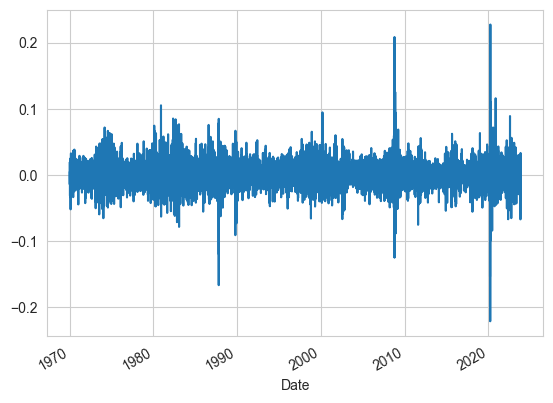

```python
ret.plot()
```

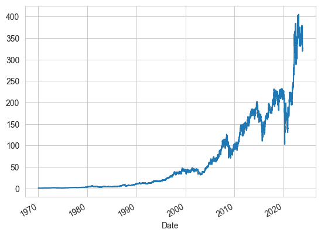

```python
(1+ret).cumprod().plot()
```

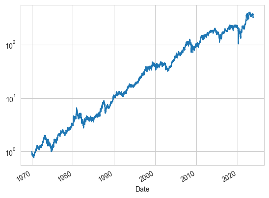

```python
(1+ret).cumprod().plot(logy=True)
```

### Distribution

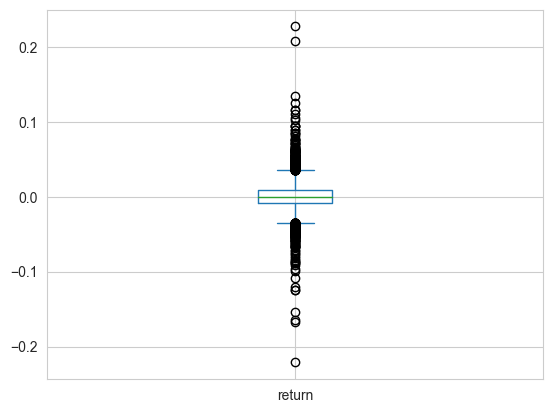

```python
ret.plot(kind="box")
```

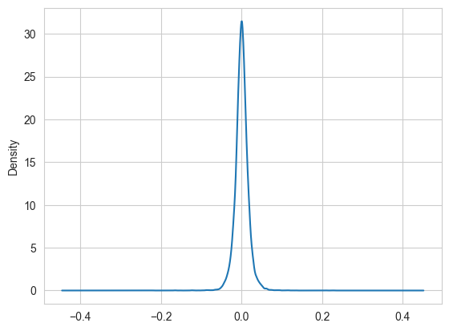

```python
ret.plot(kind="kde")
```

### Predictability

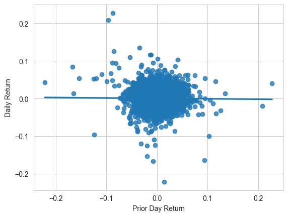

```python
import seaborn as sns
sns.regplot(x=ret.iloc[:-1], y=ret.iloc[1:], ci=None)
plt.xlabel("Prior Day Return")
plt.ylabel("Daily Return")
plt.show()
```

### Annual Returns

```python
price_annual = price.resample("Y").last()
ret_annual = price_annual.pct_change().dropna()
ret_annual.name = "annual return"
ret_annual.describe()
```

```
count    53.000000
mean      0.137076
std       0.233928
min      -0.316028
25%      -0.048960
50%       0.115426
75%       0.285149
max       0.764966
Name: annual return, dtype: float64
```

## Time Series

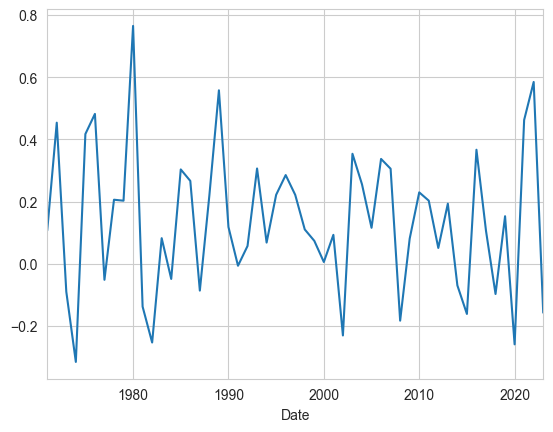

```python
ret_annual.plot()
```

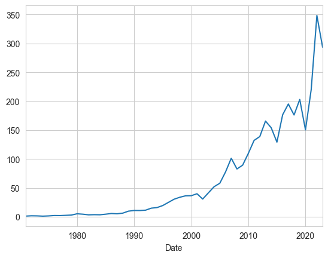

```python
(1+ret_annual).cumprod().plot()
```

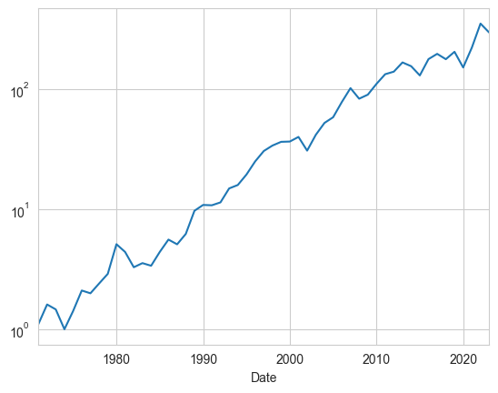

```python
(1+ret_annual).cumprod().plot(logy=True)
```

### Distribution

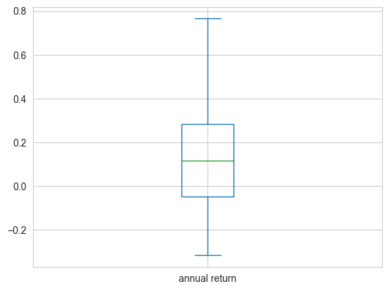

```python
ret_annual.plot(kind="box")
```

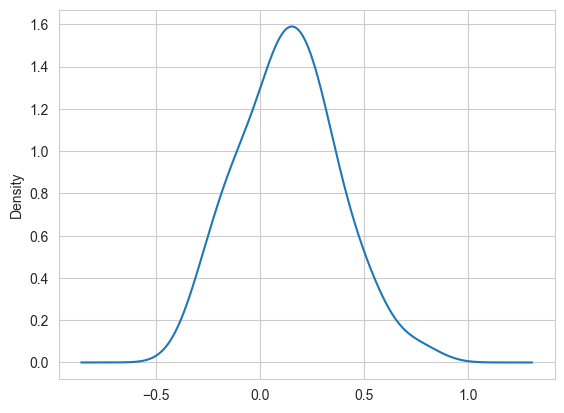

```python
ret_annual.plot(kind="kde")
```

### Predictability

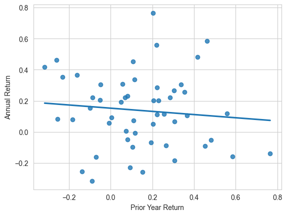

```python
sns.regplot(
    x=ret_annual.iloc[:-1],
    y=ret_annual.iloc[1:],
    ci=None
)
plt.xlabel("Prior Year Return")
plt.ylabel("Annual Return")
plt.show()
```